# Austin Bike Data Exploration

Data set and description can be found [here](https://data.austintexas.gov/Transportation-and-Mobility/Austin-MetroBike-Trips/tyfh-5r8s)

# Libraries I might use

```r
library(ISLR)
library(tidyverse)
library(randomForest)
library(gbm)
library(MASS)
library(lubridate)
library(zoo)
library(GGally)
library(e1071) #SVM and NB library
```

# Loading in the Data

```r
bikedata = read.csv("Austin_MetroBike_Trips.csv")
weatherdata = read.csv("austindaily.csv")
```

```r
bikedata
```

| Trip.ID | Membership.Type | Bicycle.ID | Checkout.Date | Checkout.Time | Checkout.Kiosk.ID | Checkout.Kiosk | Return.Kiosk.ID | Return.Kiosk | Trip.Duration.Minutes | Month | Year |
| --- | --- | --- | --- | --- | --- | --- | --- | --- | --- | --- | --- |
| 9900285854 | Annual (San Antonio B-cycle) | 207 | 10/26/2014 | 13:12:00 | 2537 | West & 6th St. | 2707 | Rainey St @ Cummings | 76 | 10 | 2014 |
| 9900285855 | 24-Hour Kiosk (Austin B-cycle) | 969 | 10/26/2014 | 13:12:00 | 2498 | Convention Center / 4th St. @ MetroRail | 2566 | Pfluger Bridge @ W 2nd Street | 58 | 10 | 2014 |
| 9900285856 | Annual Membership (Austin B-cycle) | 214 | 10/26/2014 | 13:12:00 | 2537 | West & 6th St. | 2496 | 8th & Congress | 8 | 10 | 2014 |
| 9900285857 | 24-Hour Kiosk (Austin B-cycle) | 745 | 10/26/2014 | 13:12:00 |  | Zilker Park at Barton Springs & William Barton Drive |  | Zilker Park at Barton Springs & William Barton Drive | 28 | 10 | 2014 |
| 9900285858 | 24-Hour Kiosk (Austin B-cycle) | 164 | 10/26/2014 | 13:12:00 | 2538 | Bullock Museum @ Congress & MLK |  | Convention Center/ 3rd & Trinity | 15 | 10 | 2014 |
| 9900285859 | 24-Hour Kiosk (Austin B-cycle) | 37 | 10/26/2014 | 13:12:00 |  | Zilker Park at Barton Springs & William Barton Drive | 2545 | ACC - Rio Grande & 12th | 26 | 10 | 2014 |
| 9900285860 | Annual Membership (Austin B-cycle) | 517 | 10/26/2014 | 13:12:00 | 2496 | 8th & Congress | 2561 | State Capitol Visitors Garage @ San Jacinto & 12th | 35 | 10 | 2014 |
| 9900285861 | Annual Membership (Austin B-cycle) | 996 | 10/26/2014 | 13:12:00 | 2569 | East 11th St. & San Marcos | 2499 | City Hall / Lavaca & 2nd | 11 | 10 | 2014 |
| 9900285862 | Annual Membership (Austin B-cycle) | 517 | 10/26/2014 | 13:12:00 | 2496 | 8th & Congress | 2496 | 8th & Congress | 0 | 10 | 2014 |
| 9900285863 | 24-Hour Kiosk (Austin B-cycle) | 385 | 10/26/2014 | 13:12:00 |  | Zilker Park at Barton Springs & William Barton Drive | 2545 | ACC - Rio Grande & 12th | 25 | 10 | 2014 |

[output cut: 990 more lines]

```r
weatherdata
```

| X1938.06.01 | X | X22.2 | X32.8 | X0.0 | X0 | X.1 | X.2 | X.3 | X.4 | X.5 |
| --- | --- | --- | --- | --- | --- | --- | --- | --- | --- | --- |
| 1938-06-02 | NA | 19.4 | 34.4 | 0.0 | 0 | NA | NA | NA | NA | NA |
| 1938-06-03 | NA | 21.1 | 34.4 | 0.0 | 0 | NA | NA | NA | NA | NA |
| 1938-06-04 | NA | 20.0 | 32.2 | 10.2 | 0 | NA | NA | NA | NA | NA |
| 1938-06-05 | NA | 20.0 | 34.4 | 0.5 | 0 | NA | NA | NA | NA | NA |
| 1938-06-06 | NA | 21.1 | 33.3 | 0.0 | 0 | NA | NA | NA | NA | NA |
| 1938-06-07 | NA | 21.1 | 35.0 | 0.0 | 0 | NA | NA | NA | NA | NA |
| 1938-06-08 | NA | 24.4 | 33.3 | 0.0 | 0 | NA | NA | NA | NA | NA |
| 1938-06-09 | NA | 17.8 | 30.6 | 40.6 | 0 | NA | NA | NA | NA | NA |
| 1938-06-10 | NA | 24.4 | 32.2 | 0.3 | 0 | NA | NA | NA | NA | NA |
| 1938-06-11 | NA | 23.9 | 33.3 | 0.0 | 0 | NA | NA | NA | NA | NA |

[output cut: 990 more lines]

# Data Cleaning

## Weather Data

```r
weatherclean = filter(weatherdata, year(X1938.06.01)>2012)
weatherclean = weatherclean[,c(1,2)]
colnames(weatherclean) <- c("Date","AvgTemp")
weatherclean$Date = as.Date(strptime(weatherclean$Date, format = '%Y-%m-%d'))
```

```r
summary(weatherclean)
```

```
      Date               AvgTemp
 Min.   :2013-01-01   Min.   :-9.20
 1st Qu.:2015-02-12   1st Qu.:15.20
 Median :2017-03-26   Median :22.00
 Mean   :2017-03-26   Mean   :20.86
 3rd Qu.:2019-05-07   3rd Qu.:27.50
 Max.   :2021-06-20   Max.   :34.00
                      NA's   :88
```

```r
set.seed(123)
weathercleannn=na.omit(weatherclean)
fakeweather = weathercleannn
nas = sample (1:nrow(weathercleannn), nrow(weathercleannn)*0.02934703) # The same rate of missing values as in our original data set
fakeweather$AvgTemp[nas] <- NA
fakeweather$AvgTemp = (na.locf(fakeweather$AvgTemp) + rev(na.locf(rev(fakeweather$AvgTemp))))/2 # Fills in missing values with the average of the weather values on either side
mean((weathercleannn$AvgTemp[nas]-fakeweather$AvgTemp[nas])^2)
```

```
[1] 5.109943
```

Great! We are in a reasonable range of the true temperature and can apply this method to our dataset.

```r
weatherclean$AvgTemp = (na.locf(weatherclean$AvgTemp) + rev(na.locf(rev(weatherclean$AvgTemp))))/2
```

```r
weatherclean
```

| Date | AvgTemp |
| --- | --- |
| 2013-01-01 | 9.20 |
| 2013-01-02 | 3.80 |
| 2013-01-03 | 4.70 |
| 2013-01-04 | 4.80 |
| 2013-01-05 | 7.30 |
| 2013-01-06 | 7.40 |
| 2013-01-07 | 7.00 |
| 2013-01-08 | 10.10 |
| 2013-01-09 | 13.50 |
| 2013-01-10 | 12.00 |

[output cut: 990 more lines]

## Bike data

```r
bikeclean = bikedata[,c(2,4,5,7,9,10)]
bikeclean[bikeclean==""] <- NA
bikeclean$Checkout.Time=hms(bikeclean$Checkout.Time)
bikeclean$Checkout.Date = as.Date(bikeclean$Checkout.Date,format='%m/%d/%Y')
```

```r
summary((bikeclean))
```

```
 Membership.Type    Checkout.Date        Checkout.Time                       Checkout.Kiosk     Return.Kiosk       Trip.Duration.Minutes
 Length:1342066     Min.   :2013-12-21   Min.   :0S                          Length:1342066     Length:1342066     Min.   :    0.00
 Class :character   1st Qu.:2015-12-11   1st Qu.:12H 3M 46S                  Class :character   Class :character   1st Qu.:    6.00
 Mode  :character   Median :2017-09-21   Median :15H 12M 0S                  Mode  :character   Mode  :character   Median :   13.00
                    Mean   :2017-06-08   Mean   :14H 46M 47.7450237171652S                                         Mean   :   30.59
                    3rd Qu.:2018-08-27   3rd Qu.:18H 12M 0S                                                        3rd Qu.:   28.00
                    Max.   :2021-02-28   Max.   :23H 59M 56S                                                       Max.   :34238.00
```

### Checkout Kiosk

```r
sort(unique(bikeclean$Checkout.Kiosk))
```

```
  [1] "10th & Red River"                                                 "10th/Red River"                                                   "11th & Salina"
  [4] "11th & Salina "                                                   "11th & San Jacinto"                                               "11th/Congress @ The Texas Capitol"
  [7] "11th/Salina "                                                     "11th/San Jacinto"                                                 "12th/San Jacinto @ State Capitol Visitors Garage"
 [10] "13th & San Antonio"                                               "13th/San Antonio"                                                 "16th/San Antonio"
 [13] "17th & Guadalupe"                                                 "17th/Guadalupe"                                                   "21st & Speedway @PCL"
 [16] "21st & University"                                                "21st/Guadalupe"                                                   "21st/Speedway @ PCL"
 [19] "21st/University"                                                  "22nd & Pearl"                                                     "22nd/Pearl"
 [22] "23rd & Rio Grande"                                                "23rd & San Jacinto @ DKR Stadium"                                 "23rd/Rio Grande"
 [25] "23rd/San Jacinto @ DKR Stadium"                                   "26th/Nueces"                                                      "28th/Rio Grande"
 [28] "2nd & Congress"                                                   "2nd/Congress"                                                     "2nd/Lavaca @ City Hall"
 [31] "3rd & West"                                                       "3rd/Nueces"                                                       "3rd/Trinity @ The Convention Center"
 [34] "3rd/West"                                                         "4th & Congress"                                                   "4th/Congress"
 [37] "4th/Guadalupe @ Republic Square"                                  "4th/Neches @ MetroRail Downtown"                                  "4th/Sabine"
 [40] "5th & Bowie"                                                      "5th & Campbell"                                                   "5th & San Marcos"
 [43] "5th/Bowie"                                                        "5th/Campbell"                                                     "5th/Guadalupe @ Republic Square"
```

[output cut: 51 more lines]

Oh no, we have a lot of cleaning to do here

```r
tmp = tolower(bikeclean$Checkout.Kiosk)
tmp = gsub("\\.", " ",tmp)
tmp = gsub("&", "/",tmp)
tmp = gsub("street", "",tmp)
tmp = gsub(" st ", "",tmp)
tmp = gsub(" at ", "@",tmp)
tmp = gsub("@", "/",tmp)
tmp = gsub(" ", "",tmp)
```

```r
tmp = data.frame(tmp)
tmp = separate(data = tmp, col = 1, into = c("1st","2nd","3rd","4th"), sep = "[^[:alnum:]]+")
```

```
Expected 4 pieces. Missing pieces filled with `NA` in 1323839 rows [1, 2, 3, 4, 5, 6, 7, 8, 9, 10, 11, 12, 13, 14, 15, 16, 17, 18, 19, 20, ...].
```

```r
tmp[is.na(tmp)] <- "ZZZZZ" # Sort doesn't like NA values, so I'm replacing with ZZZZ to go to the end of the row
tmp = data.frame(t(apply(tmp,1,sort))) # Sorts by row
tmp = unite(tmp, united, sep="/")
tmp = gsub("/ZZZZZ", "",tmp$united)
```

```r
tmp = gsub("3rd/theconventioncenter/trinity","3rd/conventioncenter/trinity",tmp)
tmp = gsub("slamar","southlamar",tmp)
tmp = gsub("bartonsprings/kinneyave","bartonsprings/kinney",tmp)
tmp = gsub("branding/re","rebranding",tmp)
tmp = gsub("guadalupe/op/universityco/westmall","guadalupe/utwestmall",tmp)
tmp = gsub("east6th/roberttmartinez","east6th/robertmartinez",tmp)
```

```r
bikeclean$Checkout.Kiosk = tmp
```

### Return Kiosk

```r
tmp = tolower(bikeclean$Return.Kiosk)
tmp = gsub("\\.", " ",tmp)
tmp = gsub("&", "/",tmp)
tmp = gsub("street", "",tmp)
tmp = gsub(" st ", "",tmp)
tmp = gsub(" at ", "@",tmp)
tmp = gsub("@", "/",tmp)
tmp = gsub(" ", "",tmp)
```

```r
tmp = data.frame(tmp)
tmp = separate(data = tmp, col = 1, into = c("1st","2nd","3rd","4th"), sep = "[^[:alnum:]]+")
```

```
Expected 4 pieces. Missing pieces filled with `NA` in 1323892 rows [1, 2, 3, 4, 5, 6, 7, 8, 9, 10, 11, 12, 13, 14, 15, 16, 17, 18, 19, 20, ...].
```

```r
tmp[is.na(tmp)] <- "ZZZZZ" # Sort doesn't like NA values, so I'm replacing with ZZZZ to go to the end of the row
tmp = data.frame(t(apply(tmp,1,sort))) # Sorts by row
tmp = unite(tmp, united, sep="/")
tmp = gsub("/ZZZZZ", "",tmp$united)
```

```r
tmp = gsub("3rd/theconventioncenter/trinity","3rd/conventioncenter/trinity",tmp)
tmp = gsub("slamar","southlamar",tmp)
tmp = gsub("bartonsprings/kinneyave","bartonsprings/kinney",tmp)
tmp = gsub("branding/re","rebranding",tmp)
tmp = gsub("guadalupe/op/universityco/westmall","guadalupe/utwestmall",tmp)
tmp = gsub("east6th/roberttmartinez","east6th/robertmartinez",tmp)
```

Let’s compare the drop off and pickup groups to see if we need to recode anything.

```r
comparison =  data.frame(sort(unique(tmp)),c(sort(unique(bikeclean$Checkout.Kiosk)), NA, NA, NA,NA))
colnames(comparison) <- c("Return", "Checkout")
```

```r
comparison$Return[!comparison$Return %in% comparison$Checkout]
```

```
[1] "acl2019dropoff"  "earthdayatx2017" "fantasyzilker"   "mainshop"        "missing"
```

```r
comparison$Checkout[!comparison$Checkout %in% comparison$Return]
```

```
[1] "eeyore/s2018" NA             NA             NA             NA
```

Mainshop should be recoded to shop

```r
tmp = gsub("mainshop","shop",tmp)
bikeclean$Return.Kiosk = tmp
```

### Membership types

I want to encode these as the following:

*Single Trip*

“$1 Pay by Trip Fall Special”,“Single Trip”,“Try Before You Buy Special”,“$1 Pay by Trip Winter Special”,“RideScout Single Ride”,“Single Trip”,“Single Trip Ride”, “Pay-as-you-ride”,“Single Trip (Pay-as-you-ride)”,“24-Hour Kiosk (Austin B-cycle)”,“24 Hour Walk Up Pass”,“Walk Up”

*Daily*

“24-Hour-Online (Austin B-cycle)”,“24-Hour Membership (Austin B-cycle)”,“Explorer”,“Explorer ($8 plus tax)”

*3-Day*

“3-Day Explorer”,“Weekender”,“3-Day Weekender”,“Weekender ($15 plus tax)”

*Weekly*

“7-Day”,7-Day Membership (Austin B-cycle),“7-Day Membership (Austin B-cycle)”

*Monthly*

“Local30 ($11 plus tax)”,“Local30”,“Local31”

*Annual*

“Annual”,“Annual Membership”,“Annual Pass”,“Annual Plus”,“Local365”,“Local365 ($80 plus tax)”,“Local365 Youth (age 13-17 riders)- 1/2,”Local365+Guest Pass“,”Annual“,”Annual Member“,”Annual Membership“,”Annual Membership (Austin B-cycle)“,”Annual Pass (30 minute)“,”Annual Plus Membership“,”Local365- 1/2 off Anniversary Special“,”Local365 Youth (age 13-17 riders)“,Special” “Local365 Youth with helmet (age 13-17 riders)”,“Local365+Guest Pass- 1/2 off Anniversary Special”,“Membership: pay once one-year commitment”

*Student*

“HT Ram Membership”,“Semester Membership”,“UT Student Membership”,“Semester Membership (Austin B-cycle)”,“U.T. Student Membership”,“U.T. Student Membership”

*Event*

“ACL 2019 Pass”,“ACL Weekend Pass Special (Austin B-cycle)”,“FunFunFun Fest 3 Day Pass”

*Share*

“Annual (Broward B-cycle)”,“Annual (Denver B-cycle)”,“Annual (Kansas City B-cycle)”,“Annual (Nashville B-cycle)”,“Annual (San Antonio B-cycle)”,“Annual Member (Houston B-cycle)”,“Annual Membership (Charlotte B-cycle)”,“Annual Membership (GREENbike)”,“Denver B-cycle Founder”,“Heartland Pass (Annual Pay)”,“Madtown Monthly”,“Republic Rider”,“Annual (Cincy Red Bike)”,“Annual (Omaha B-cycle)”,“Annual (Madison B-cycle)”,“Annual (Denver Bike Sharing)”,“Annual Membership (Fort Worth Bike Sharing)”,“Heartland Pass (Monthly Pay)”,“Republic Rider (Annual)”

*Other* “Aluminum Access”,“Founding Member (Austin B-cycle)”,“Founding Member”

*Missing* NA, “PROHIBITED”, “RESTRICTED”

```r
bikeclean$Membership.Type[is.na(bikeclean$Membership.Type)] = "missing"
bikeclean$Membership.Type[which(bikeclean$Membership.Type %in% c("PROHIBITED", "RESTRICTED"))]="missing"
bikeclean$Membership.Type[which(bikeclean$Membership.Type %in% c("3-Day Explorer","Weekender","3-Day Weekender","Weekender ($15 plus tax)"))]="3 Day"
bikeclean$Membership.Type[which(bikeclean$Membership.Type %in% c("$1 Pay by Trip Fall Special","Single Trip","Try Before You Buy Special","$1 Pay by Trip Winter Special","RideScout Single Ride","Single Trip ","Single Trip Ride", "Pay-as-you-ride","Single Trip (Pay-as-you-ride)","24-Hour Kiosk (Austin B-cycle)", "24 Hour Walk Up Pass","Walk Up"))]="Single Trip"
bikeclean$Membership.Type[which(bikeclean$Membership.Type %in% c("24-Hour-Online (Austin B-cycle)","24-Hour Membership (Austin B-cycle)","Explorer","Explorer ($8 plus tax)"))]="Daily"
bikeclean$Membership.Type[which(bikeclean$Membership.Type%in%c("7-Day","7-Day Membership (Austin B-cycle)","7-Day Membership (Austin B-cycle)"))]="Weekly"
bikeclean$Membership.Type[which(bikeclean$Membership.Type%in%c("Local30 ($11 plus tax)","Local30","Local31"))]="Monthly"
bikeclean$Membership.Type[which(bikeclean$Membership.Type%in%c("Annual ","Annual Membership ","Annual Pass","Annual Plus","Local365","Local365 ($80 plus tax)","Local365 Youth (age 13-17 riders)- 1/2" ,"Local365+Guest Pass","Annual","Annual Member","Annual Membership","Annual Membership (Austin B-cycle)","Annual Pass (30 minute)","Annual Plus Membership","Local365- 1/2 off Anniversary Special","Local365 Youth (age 13-17 riders)", "Local365 Youth with helmet (age 13-17 riders)","Local365+Guest Pass- 1/2 off Anniversary Special","Membership: pay once  one-year commitment","Local365 Youth (age 13-17 riders)- 1/2 off Special"))]="Annual"
bikeclean$Membership.Type[which(bikeclean$Membership.Type%in%c("HT Ram Membership","Semester Membership","UT Student Membership","Semester Membership (Austin B-cycle)","U.T. Student Membership","U.T. Student Membership"))]="Student"
bikeclean$Membership.Type[which(bikeclean$Membership.Type%in%c("ACL 2019 Pass","ACL Weekend Pass Special (Austin B-cycle)","FunFunFun Fest 3 Day Pass"))]="Event"
bikeclean$Membership.Type[which(bikeclean$Membership.Type%in%c("Aluminum Access","Founding Member (Austin B-cycle)","Founding Member"))]="Other"

bikeclean$Membership.Type[which(bikeclean$Membership.Type%in%c("Annual (Broward B-cycle)","Annual (Denver B-cycle)","Annual (Kansas City B-cycle)","Annual (Nashville B-cycle)","Annual (San Antonio B-cycle)","Annual Member (Houston B-cycle)","Annual Membership (Charlotte B-cycle)","Annual Membership (GREENbike)","Denver B-cycle Founder","Heartland Pass (Annual Pay)","Madtown Monthly","Republic Rider","Annual (Cincy Red Bike)","Annual (Omaha B-cycle)","Annual (Madison B-cycle)","Annual (Denver Bike Sharing)","Annual Membership (Fort Worth Bike Sharing)","Heartland Pass (Monthly Pay)","Republic Rider (Annual)", "Annual Membership (Indy - Pacers Bikeshare )", "Annual (Boulder B-cycle)"))]="Share"
```

```r
sort(unique(bikeclean$Membership.Type))
```

```
 [1] "3 Day"       "Annual"      "Daily"       "Event"       "missing"     "Monthly"     "Other"       "Share"       "Single Trip" "Student"
[11] "Weekly"
```

Looking good! I might try and predict our missing membership types if I have time.

## Merging our Datasets

```r
merged = merge(bikeclean,weatherclean,by.x = "Checkout.Date",by.y ="Date")
```

```r
saveRDS(merged,file = 'merged.rds')
```

Now I don’t have to run everything above this EVERY time I need to start over.

```r
merged = readRDS("merged.rds")
merged$Membership.Type=factor(merged$Membership.Type)
```

# Data visualization

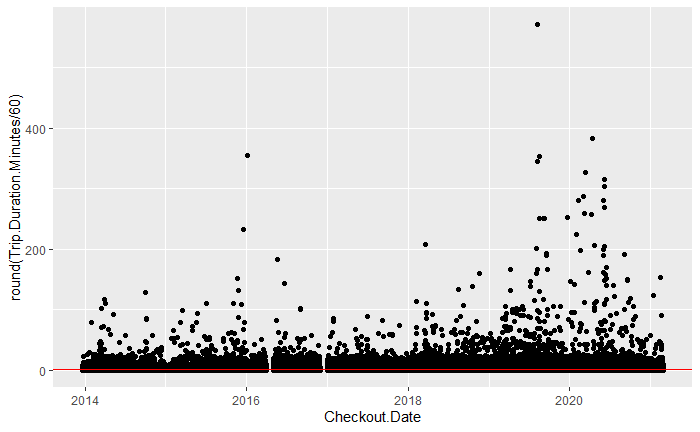

```r
ggplot(merged)+
  geom_point(aes(x = Checkout.Date, y=round(Trip.Duration.Minutes/60)))+
  geom_hline(yintercept=1,color = "red")
```

Trips are expected to be at 1 hour in length. Any more than that and there is a fine associated with each minute over you ride. as time has gone on, more people aren’t checking their bikes in on time.

I wonder what’s up with the weird gaps in 2016.

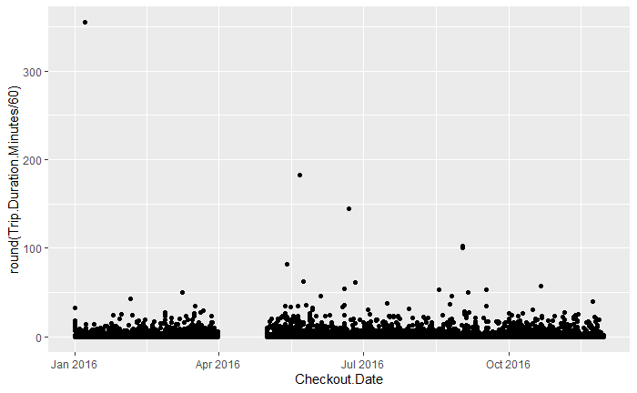

```r
ggplot(merged[which(year(merged$Checkout.Date)==2016),])+
    geom_point(aes(x = Checkout.Date, y=round(Trip.Duration.Minutes/60)))
```

[figure not shown]

```r
ggplot(merged[which(year(merged$Checkout.Date)==2016 & month(merged$Checkout.Date)==4),])+
      geom_point(aes(x = Checkout.Date, y=round(Trip.Duration.Minutes/60)))
```

```r
merged[which(year(merged$Checkout.Date)==2016 & month(merged$Checkout.Date)==4),]
```

| Checkout.Date | Membership.Type | Checkout.Time | Checkout.Kiosk | Return.Kiosk | Trip.Duration.Minutes | AvgTemp |
| --- | --- | --- | --- | --- | --- | --- |

Great, no data for that month.

```r
merged[which(year(merged$Checkout.Date)==2016 & month(merged$Checkout.Date)==12),]
```

| Checkout.Date | Membership.Type | Checkout.Time | Checkout.Kiosk | Return.Kiosk | Trip.Duration.Minutes | AvgTemp |
| --- | --- | --- | --- | --- | --- | --- |

Same with December.

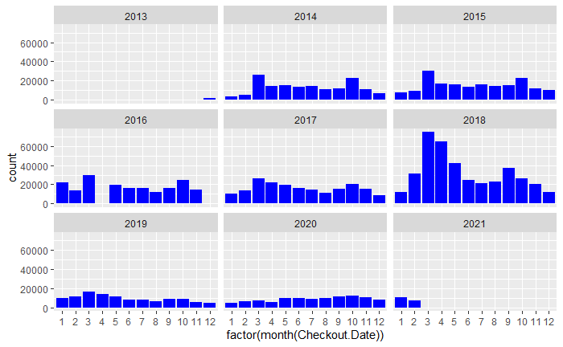

```r
ggplot(merged)+
  geom_bar(aes(x=factor(month(Checkout.Date))), fill = "blue")+
  facet_wrap(~year(Checkout.Date))
```

We can see there is a cyclical nature to the number of trips taken per month. Intuitively, there are more riders when the weather is nice.

```r
summary(merged$AvgTemp)
```

```
   Min. 1st Qu.  Median    Mean 3rd Qu.    Max.
  -9.20   17.30   22.40   21.81   27.20   34.00
```

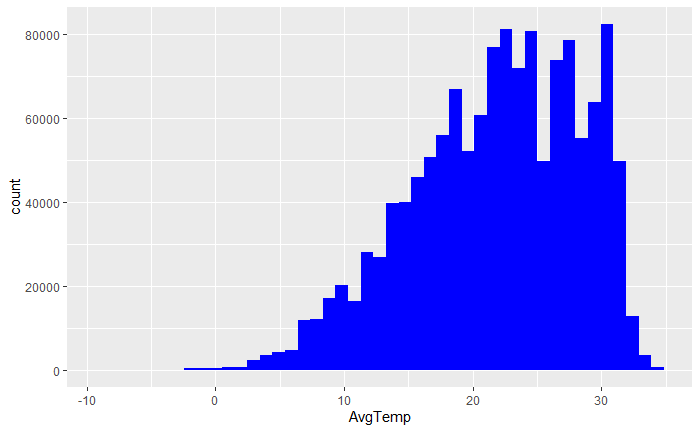

```r
ggplot(merged)+
  geom_histogram(aes(x= AvgTemp), bins = 45, fill = "blue")
```

Most people ride between and 12 and 32 degrees Celsius

```r
merged %>%
  group_by(Checkout.Kiosk) %>%
  summarise(Departing_Bikes = length(Checkout.Kiosk)) %>% arrange(.,desc(Departing_Bikes))
```

| Checkout.Kiosk | Departing_Bikes |
| --- | --- |
| 21st/pcl/speedway | 80180 |
| riverside/southlamar | 47184 |
| cummings/rainey | 40915 |
| 2nd/cityhall/lavaca | 39195 |
| 2nd/congress | 38286 |
| 5th/bowie | 37367 |
| davis/rainey | 34357 |
| 4th/congress | 33475 |
| deankeeton/speedway | 31515 |
| 4th/conventioncenter/metrorail | 31381 |

[output cut: 113 more lines]

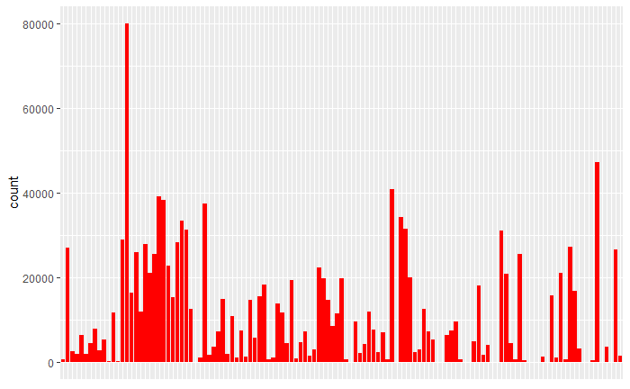

```r
merged %>%
  ggplot() +
  geom_bar(aes(x=Checkout.Kiosk), fill = "red")+
  theme(axis.title.x=element_blank(), axis.text.x=element_blank(), axis.ticks.x=element_blank())
```

Bikes leave the campus Speedway at a very high rate

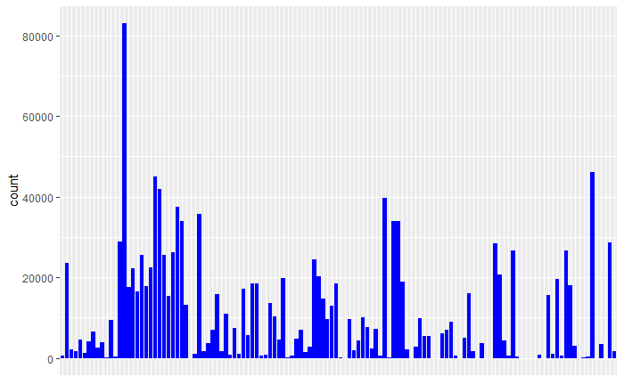

```r
merged %>%
  ggplot() +
  geom_bar(aes(x=Return.Kiosk), fill = "blue")+
  theme(axis.title.x=element_blank(), axis.text.x=element_blank(), axis.ticks.x=element_blank())
```

```r
merged %>%
  group_by(Return.Kiosk) %>%
  summarise(Departing_Bikes = length(Return.Kiosk)) %>% arrange(.,desc(Departing_Bikes))
```

| Return.Kiosk | Departing_Bikes |
| --- | --- |
| 21st/pcl/speedway | 83092 |
| riverside/southlamar | 46046 |
| 2nd/cityhall/lavaca | 44933 |
| 2nd/congress | 41886 |
| cummings/rainey | 39744 |
| 4th/congress | 37553 |
| 5th/bowie | 35723 |
| deankeeton/speedway | 34061 |
| 4th/conventioncenter/metrorail | 34010 |
| davis/rainey | 34005 |

[output cut: 116 more lines]

Even more are returned there

# Daily Differential Requiring Human Intervention

```r
checkout = merged %>% group_by(Checkout.Date, Checkout.Kiosk) %>% tally() %>% spread(Checkout.Date, n)
checkout = checkout[-which(checkout$Checkout.Kiosk == "eeyore/s2018"),]
return = merged %>% group_by(Checkout.Date, Return.Kiosk) %>% tally() %>% spread(Checkout.Date, n)
return = return[-which(!return$Return.Kiosk %in% checkout$Checkout.Kiosk),]
checkout[is.na(checkout)] = 0
return[is.na(return)]= 0
```

```r
diff = data.frame(return$Return.Kiosk,return[,-1]-checkout[,-1])
```

```r
diff
```

| return.Return.Kiosk | X2013.12.21 | X2013.12.22 | X2013.12.23 | X2013.12.24 | X2013.12.25 | X2013.12.26 | X2013.12.27 | X2013.12.28 | X2013.12.29 | X2013.12.30 | X2013.12.31 | X2014.01.01 | X2014.01.02 | X2014.01.03 | X2014.01.04 | X2014.01.05 | X2014.01.06 | X2014.01.07 | X2014.01.08 | X2014.01.09 | X2014.01.10 | X2014.01.11 | X2014.01.12 | X2014.01.13 | X2014.01.14 | X2014.01.15 | X2014.01.16 | X2014.01.17 | X2014.01.18 | … |
| --- | --- | --- | --- | --- | --- | --- | --- | --- | --- | --- | --- | --- | --- | --- | --- | --- | --- | --- | --- | --- | --- | --- | --- | --- | --- | --- | --- | --- | --- | --- |
| 10th/redriver | 0 | 0 | 0 | 0 | 0 | 0 | 0 | 0 | 0 | 0 | 0 | 0 | 0 | 0 | 0 | 0 | 0 | 0 | 0 | 0 | 0 | 0 | 0 | 0 | 0 | 0 | 0 | 0 | 0 | … |
| 11th/capitolstation/congress | -5 | -7 | -2 | -6 | 3 | -2 | 1 | -4 | 2 | 0 | 2 | 1 | -17 | -4 | -4 | -3 | -1 | -3 | -1 | -1 | -3 | -11 | -1 | -4 | 5 | -2 | 6 | -3 | -14 | … |
| 11th/congress/thetexascapitol | 0 | 0 | 0 | 0 | 0 | 0 | 0 | 0 | 0 | 0 | 0 | 0 | 0 | 0 | 0 | 0 | 0 | 0 | 0 | 0 | 0 | 0 | 0 | 0 | 0 | 0 | 0 | 0 | 0 | … |
| 11th/salina | 0 | 0 | 0 | 0 | 0 | 0 | 0 | 0 | 0 | 0 | 0 | 0 | 0 | 0 | 0 | 0 | 0 | 0 | 0 | 0 | 0 | 0 | 0 | 0 | 0 | 0 | 0 | 0 | 0 | … |
| 11th/sanjacinto | 0 | 0 | 0 | 0 | 0 | 0 | 0 | 0 | 0 | 0 | 0 | 0 | 0 | 0 | 0 | 0 | 0 | 0 | 0 | 0 | 0 | 0 | 0 | 0 | 0 | 0 | 0 | 0 | 0 | … |
| 12th/acc/riogrande | 0 | 0 | 0 | 0 | 0 | 0 | 0 | 0 | 0 | 0 | 0 | 0 | 0 | 0 | 0 | 0 | 0 | 0 | 0 | 0 | 0 | 0 | 0 | 0 | 0 | 0 | 0 | 0 | 0 | … |
| 12th/acc/west | 0 | 0 | 0 | 0 | 0 | 0 | 0 | 0 | 0 | 0 | 0 | 0 | 0 | 0 | 0 | 0 | 0 | 0 | 0 | 0 | 0 | 0 | 0 | 0 | 0 | 0 | 0 | 0 | 0 | … |
| 12th/sanjacinto/statecapitolvisitorsgarage | 0 | 0 | 0 | 0 | 0 | 0 | 0 | 0 | 0 | 0 | 0 | 0 | 0 | 0 | 0 | 0 | 0 | 0 | 0 | 0 | 0 | 0 | 0 | 0 | 0 | 0 | 0 | 0 | 0 | … |
| 13th/sanantonio | 0 | 0 | 0 | 0 | 0 | 0 | 0 | 0 | 0 | 0 | 0 | 0 | 0 | 0 | 0 | 0 | 0 | 0 | 0 | 0 | 0 | 0 | 0 | 0 | 0 | 0 | 0 | 0 | 0 | … |
| 14th/colorado/statecapitol | 0 | 0 | 0 | 0 | 0 | 0 | 0 | 0 | 0 | 0 | 0 | 0 | 0 | 0 | 0 | 0 | 0 | 0 | 0 | 0 | 0 | 0 | 0 | 0 | 0 | 0 | 0 | 0 | 0 | … |

[output cut: 112 more lines]

```r
daily_diff = data.frame(colSums(abs(diff[,-1])))
daily_diff <- rownames_to_column(daily_diff, "Date")
daily_diff$Date = gsub( "X", "", daily_diff$Date)
daily_diff$Date = as.Date(strptime(daily_diff$Date, format = '%Y.%m.%d'))
colnames(daily_diff) = c("Date","Diff")
```

```r
daily_diff
```

| Date | Diff |
| --- | --- |
| 2013-12-21 | 24 |
| 2013-12-22 | 34 |
| 2013-12-23 | 26 |
| 2013-12-24 | 30 |
| 2013-12-25 | 24 |
| 2013-12-26 | 18 |
| 2013-12-27 | 32 |
| 2013-12-28 | 50 |
| 2013-12-29 | 38 |
| 2013-12-30 | 14 |

[output cut: 990 more lines]

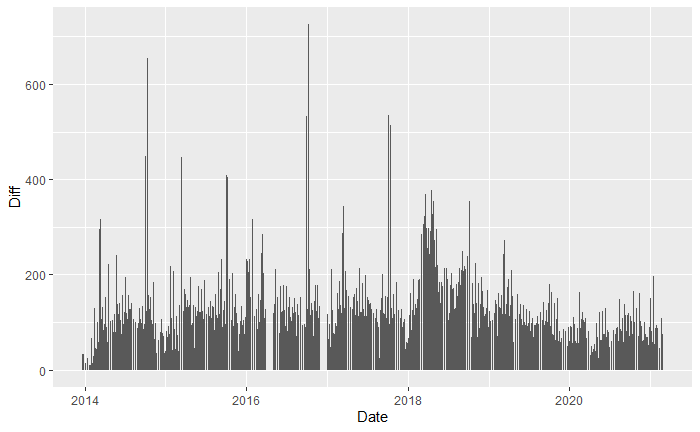

```r
ggplot(daily_diff)+
  geom_bar(aes(x=Date, y = Diff), stat = "identity")
```

```r
daily_diff = merge(daily_diff,weatherclean,by.x = "Date",by.y ="Date")
daily_diff$month = month(daily_diff$Date)
```

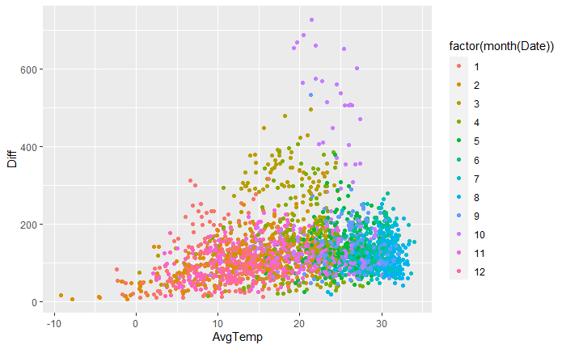

```r
xgrid = seq(-10,50,.001)
ggplot(daily_diff) +
  geom_point(aes(x = AvgTemp, y = Diff, color =factor(month(Date))))
```

This seems like one of those things we would want to predict so that we can know staffing levels. Let’s try to predict it with a random forest.

## Random Forest

```r
head(daily_diff)
```

|  | Date | Diff | AvgTemp | month |
| --- | --- | --- | --- | --- |
| 1 | 2013-12-21 | 24 | 12.7 | 12 |
| 2 | 2013-12-22 | 34 | 8.5 | 12 |
| 3 | 2013-12-23 | 26 | 6.0 | 12 |
| 4 | 2013-12-24 | 30 | 7.3 | 12 |
| 5 | 2013-12-25 | 24 | 9.6 | 12 |
| 6 | 2013-12-26 | 18 | 9.1 | 12 |

```r
set.seed(123)
train = sample (1:nrow(daily_diff), nrow(daily_diff)/2)
```

```r
rf.dd= randomForest(Diff ~ Date + AvgTemp,data=daily_diff, subset=train)
yhat.rf = predict(rf.dd ,newdata=daily_diff[- train ,])
mean((yhat.rf-daily_diff[-train, "Diff"])^2)
```

```
[1] 2518.162
```

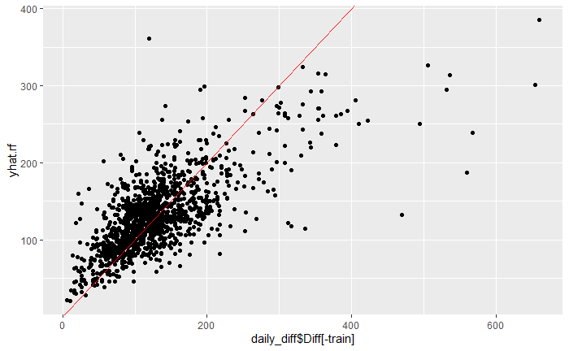

```r
ggplot()+
  geom_point(aes(x=daily_diff$Diff[-train],y = yhat.rf))+
  geom_abline(color = "red")
```

```r
summary(daily_diff)
```

```
      Date                 Diff          AvgTemp          month
 Min.   :2013-12-21   Min.   :  6.0   Min.   :-9.20   Min.   : 1.000
 1st Qu.:2015-09-24   1st Qu.: 90.0   1st Qu.:15.00   1st Qu.: 3.000
 Median :2017-08-26   Median :118.0   Median :22.10   Median : 6.000
 Mean   :2017-08-03   Mean   :131.3   Mean   :20.84   Mean   : 6.393
 3rd Qu.:2019-05-29   3rd Qu.:154.0   3rd Qu.:27.60   3rd Qu.: 9.000
 Max.   :2021-02-28   Max.   :726.0   Max.   :34.00   Max.   :12.000
```

Not terrible, but there are some areas where the model gets it pretty wrong

Let’s try boosting

```r
set.seed(12)
boost.dd=gbm(Diff~AvgTemp+month(Date)+year(Date)+day(Date),data=daily_diff[train ,], distribution="gaussian",n.trees=5000, shrinkage = .01,interaction.depth = 3)
```

```r
best.iter <- gbm.perf(boost.dd, method = "OOB", plot = FALSE)
```

```
OOB generally underestimates the optimal number of iterations although predictive performance is reasonably competitive. Using cv_folds>1 when calling gbm usually results in improved predictive performance.
```

```r
yhat.boost=predict (boost.dd ,newdata =daily_diff[-train ,], n.trees=best.iter)
mean((yhat.boost-daily_diff[-train, "Diff"])^2)
```

```
[1] 3167.117
```

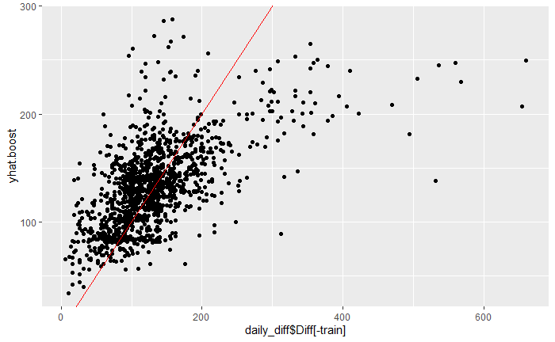

```r
ggplot()+
  geom_point(aes(x=daily_diff$Diff[-train],y = yhat.boost))+
  geom_abline(color = "red")
```

```r
daily_diff[daily_diff$Diff>300, 'Date']
```

```
 [1] "2014-03-12" "2014-03-14" "2014-03-15" "2014-10-03" "2014-10-04" "2014-10-05" "2014-10-10" "2014-10-11" "2014-10-12" "2015-03-13" "2015-03-14"
[12] "2015-03-15" "2015-03-16" "2015-03-17" "2015-03-18" "2015-03-19" "2015-03-20" "2015-10-02" "2015-10-03" "2015-10-04" "2015-10-09" "2015-10-10"
[23] "2015-10-11" "2016-01-23" "2016-01-30" "2016-01-31" "2016-03-12" "2016-03-13" "2016-03-16" "2016-03-19" "2016-09-30" "2016-10-01" "2016-10-02"
[34] "2016-10-07" "2016-10-08" "2016-10-09" "2017-03-13" "2017-03-14" "2017-03-15" "2017-03-16" "2017-03-17" "2017-03-18" "2017-10-06" "2017-10-07"
[45] "2017-10-08" "2017-10-13" "2017-10-14" "2017-10-15" "2018-02-19" "2018-03-01" "2018-03-02" "2018-03-06" "2018-03-08" "2018-03-09" "2018-03-10"
[56] "2018-03-11" "2018-03-13" "2018-03-14" "2018-03-15" "2018-03-16" "2018-03-17" "2018-03-18" "2018-03-20" "2018-03-21" "2018-03-22" "2018-03-23"
[67] "2018-03-28" "2018-03-29" "2018-04-02" "2018-04-04" "2018-04-06" "2018-04-10" "2018-04-11" "2018-04-12" "2018-04-13" "2018-04-17" "2018-04-18"
[78] "2018-04-19" "2018-04-20" "2018-04-23" "2018-04-26" "2018-04-27" "2018-05-01" "2018-05-03" "2018-05-08" "2018-10-05" "2018-10-06" "2018-10-07"
[89] "2018-10-13"
```

## ANN Try

```r
library(neuralnet)
library(NeuralNetTools)
```

```r
daily_diff$year = year(daily_diff$Date)
daily_diff$day = day(daily_diff$Date)
dd.scaled <- as.data.frame(scale(daily_diff[,-1]))
min.diff <- min(daily_diff$Diff)
max.diff <- max(daily_diff$Diff)
```

```r
dd.scaled
```

| Diff | AvgTemp | month | year | day |
| --- | --- | --- | --- | --- |
| 0.025000000 | -1.024852144 | 1.6101682 | -1.9572685 | 0.59543663 |
| 0.038888889 | -1.553569665 | 1.6101682 | -1.9572685 | 0.70903239 |
| 0.027777778 | -1.868282475 | 1.6101682 | -1.9572685 | 0.82262815 |
| 0.033333333 | -1.704631814 | 1.6101682 | -1.9572685 | 0.93622391 |
| 0.025000000 | -1.415096028 | 1.6101682 | -1.9572685 | 1.04981967 |
| 0.016666667 | -1.478038590 | 1.6101682 | -1.9572685 | 1.16341542 |
| 0.036111111 | -1.339564954 | 1.6101682 | -1.9572685 | 1.27701118 |
| 0.061111111 | -1.326976442 | 1.6101682 | -1.9572685 | 1.39060694 |
| 0.044444444 | -1.415096028 | 1.6101682 | -1.9572685 | 1.50420270 |
| 0.011111111 | -2.170406773 | 1.6101682 | -1.9572685 | 1.61779845 |

[output cut: 990 more lines]

```r
dd.scaled$Diff <- scale(daily_diff$Diff, center = min.diff, scale = max.diff - min.diff)
```

```r
dd.split <- sample(dim(daily_diff)[1],dim(daily_diff)[1]/2 )
# Train-test split
dd.train.scaled <- dd.scaled[dd.split, ]
dd.test.scaled <- dd.scaled[-dd.split, ]
```

```r
generate.full.fmla<- function(df, response){
  names(df)[!(names(df) == response)]%>%
    paste(.,collapse = "+")%>%
     paste(response, "~", .)%>%
    formula(.)
}
dd.nn.fmla <- generate.full.fmla(dd.train.scaled, "Diff")
dd.nn.5.3 <- neuralnet(dd.nn.fmla
                           , data=dd.train.scaled
                           , hidden=c(5,3)
                           , linear.output=TRUE)
dd.nn.8 <- neuralnet(dd.nn.fmla
                           , data=dd.train.scaled
                           , hidden=8
                           , linear.output=TRUE)
rf.dd= randomForest(dd.nn.fmla,data=dd.train.scaled)
```

```r
fitness.measures <- function(test, model, response){
  data.frame(y = test[, response], yhat = predict(model, newdata = test))%>%
    summarize(MSE = sum((y-yhat)^2)/n(), MAD = sum(abs(y - yhat))/n())%>%
    mutate(RMSE = sqrt(MSE))
}
```

```r
fitness.measures(dd.test.scaled, dd.nn.5.3, "Diff")
```

| MSE | MAD | RMSE |
| --- | --- | --- |
| 0.007787654 | 0.05498104 | 0.08824769 |

```r
fitness.measures(dd.test.scaled, dd.nn.8, "Diff")
```

| MSE | MAD | RMSE |
| --- | --- | --- |
| 0.007905018 | 0.05589296 | 0.08891017 |

```r
fitness.measures(dd.test.scaled, rf.dd, "Diff")
```

| MSE | MAD | RMSE |
| --- | --- | --- |
| 0.006407214 | 0.05059617 | 0.08004507 |

```r
models = list()

for (i in 3:12){
  nn <- neuralnet(dd.nn.fmla
                           , data=dd.train.scaled
                           , hidden= i
                           , linear.output=TRUE)
  models[[i]] <- nn
}
```

```r
mse = list()
for (i in 3:12) {
 mse[i] <- (fitness.measures(dd.test.scaled, models[[i]], "Diff")[1] * ((max.diff-min.diff)**2))
}

mse[1] <- fitness.measures(dd.test.scaled, dd.nn.5.3, "Diff")[1] * ((max.diff-min.diff)**2)
mse[2] <- fitness.measures(dd.test.scaled, rf.dd, "Diff")[1] * ((max.diff-min.diff)**2)

mse
```

```
[[1]]
[1] 4037.12

[[2]]
[1] 3321.5

[[3]]
[1] 4496.449

[[4]]
[1] 4440.882

[[5]]
[1] 4367.814

[[6]]
[1] 4364.864

[[7]]
[1] 4650.306

[[8]]
[1] 4138.011

[[9]]
[1] 3994.522

[[10]]
[1] 3924.122

[[11]]
[1] 4297.862

[[12]]
[1] 4095.124
```

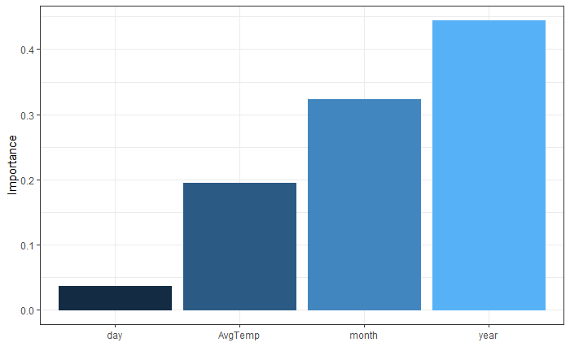

```r
NeuralNetTools::garson(models[[10]])
```

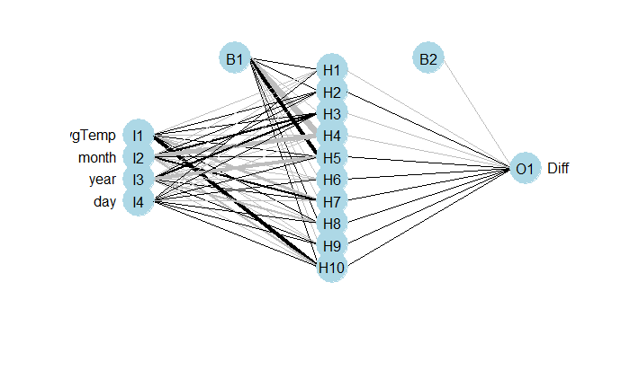

```r
NeuralNetTools::plotnet(models[[10]])
```

# Trip duration

```r
ggplot(merged)+
  geom_point(aes(x=Checkout.Kiosk, y = Trip.Duration.Minutes ))+
  theme(axis.title.x=element_blank(), axis.text.x=element_blank(), axis.ticks.x=element_blank())
```

[output not shown]

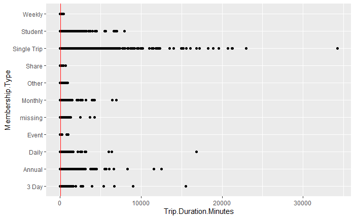

```r
ggplot(merged)+
  geom_point(aes(y=Membership.Type, x = Trip.Duration.Minutes ))+
  geom_vline(xintercept = 60, color = "red")
```

Single trips run long the most often, but there a lot of late trips period.

```r
merged$late = ifelse(merged$Trip.Duration.Minutes > 60,1 ,0)
```

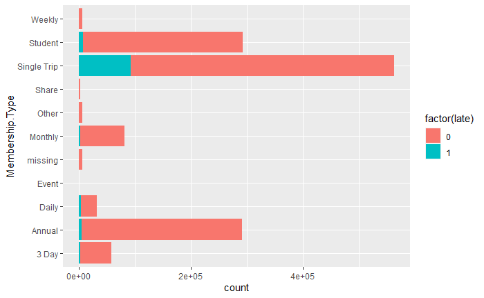

```r
ggplot(merged)+
  geom_bar(aes(y = Membership.Type,fill = factor(late)))
```

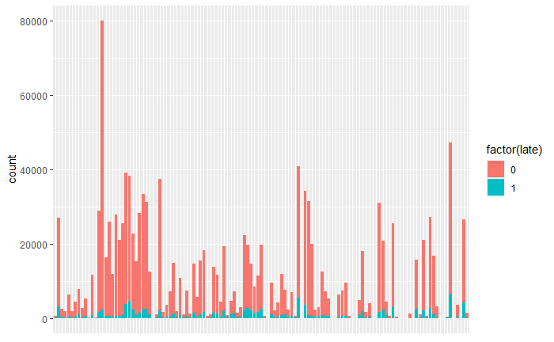

```r
ggplot(merged)+
  geom_bar(aes(x = Checkout.Kiosk,fill = factor(late)))+
  theme(axis.title.x=element_blank(), axis.text.x=element_blank(), axis.ticks.x=element_blank())
```

```r
head(merged)
```

|  | Checkout.Date | Membership.Type | Checkout.Time | Checkout.Kiosk | Return.Kiosk | Trip.Duration.Minutes | AvgTemp | late |
| --- | --- | --- | --- | --- | --- | --- | --- | --- |
| 1 | 2013-12-21 | Single Trip | 15H 12M 0S | 5th/bowie | 5th/bowie | 83 | 12.7 | 1 |
| 2 | 2013-12-21 | Single Trip | 16H 12M 0S | 11th/capitolstation/congress | 5th/bowie | 22 | 12.7 | 0 |
| 3 | 2013-12-21 | Annual | 16H 12M 0S | 4th/congress | 4th/conventioncenter/metrorail | 1 | 12.7 | 0 |
| 4 | 2013-12-21 | Single Trip | 15H 12M 0S | 11th/capitolstation/congress | 4th/congress | 51 | 12.7 | 0 |
| 5 | 2013-12-21 | Single Trip | 15H 12M 0S | 2nd/cityhall/lavaca | 8th/congress | 238 | 12.7 | 1 |
| 6 | 2013-12-21 | Single Trip | 16H 12M 0S | 2nd/congress | 2nd/congress | 28 | 12.7 | 0 |

```r
temp_merged = merged#[year(merged$Checkout.Date)>2018,]
temp_merged$Checkout.Kiosk = factor(temp_merged$Checkout.Kiosk)
temp_merged$hour = hour(temp_merged$Checkout.Time)
temp_merged$Membership.Type = factor(temp_merged$Membership.Type)
```

```r
set.seed(123)
train = sample (1:nrow(temp_merged), nrow(temp_merged)/2)
```

```r
set.seed(12)
boost.merged=gbm(Trip.Duration.Minutes~Membership.Type+hour + Checkout.Kiosk+AvgTemp,data=temp_merged[train ,], distribution="gaussian",n.trees=500, shrinkage = .1)
```

[output not shown]

|  | var | rel.inf |
| --- | --- | --- |
| Checkout.Kiosk | Checkout.Kiosk | 46.99485 |
| AvgTemp | AvgTemp | 32.20728 |
| Membership.Type | Membership.Type | 10.63480 |
| hour | hour | 10.16306 |

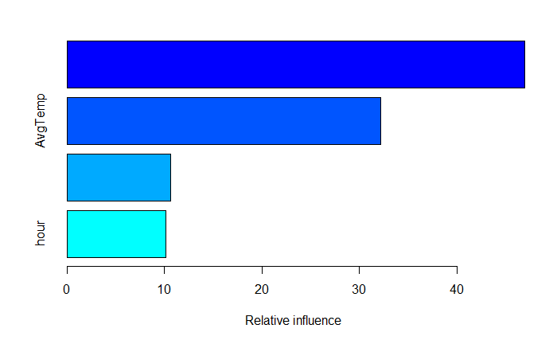

```r
summary(boost.merged)
```

```
OOB generally underestimates the optimal number of iterations although predictive performance is reasonably competitive. Using cv_folds>1 when calling gbm usually results in improved predictive performance.
```

```
[1] 34
attr(,"smoother")
Call:
loess(formula = object$oobag.improve ~ x, enp.target = min(max(4,
    length(x)/10), 50))

Number of Observations: 500
Equivalent Number of Parameters: 39.85
Residual Standard Error: 4.938
```

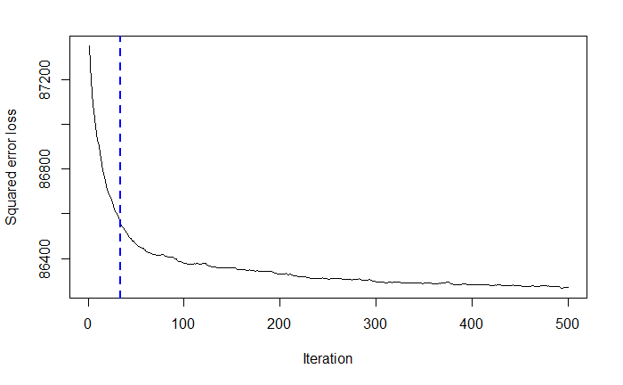

```r
gbm.perf(boost.merged, method = "OOB")
```

```r
pred = predict.gbm(object = boost.merged,newdata = temp_merged[-train,], n.trees = 34)
```

```r
mean((pred - temp_merged$Trip.Duration.Minutes[-train])^2)
```

```
[1] 54794.91
```

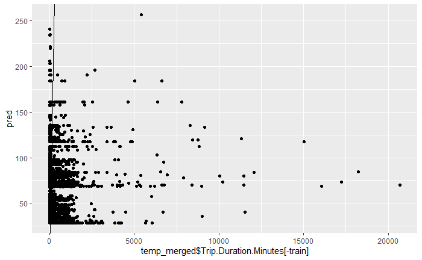

```r
ggplot()+
  geom_point(aes(x=temp_merged$Trip.Duration.Minutes[-train], y = pred))+
  geom_abline()
```

```r
head(temp_merged)
```

[output not shown]

```r
boost.merged=gbm(late~Membership.Type+hour + Checkout.Kiosk+AvgTemp,data=temp_merged[train ,], distribution="bernoulli",n.trees=500, shrinkage = .1)
```

|  | var | rel.inf |
| --- | --- | --- |
| Membership.Type | Membership.Type | 80.1761708 |
| Checkout.Kiosk | Checkout.Kiosk | 16.7304354 |
| hour | hour | 2.7137740 |
| AvgTemp | AvgTemp | 0.3796197 |

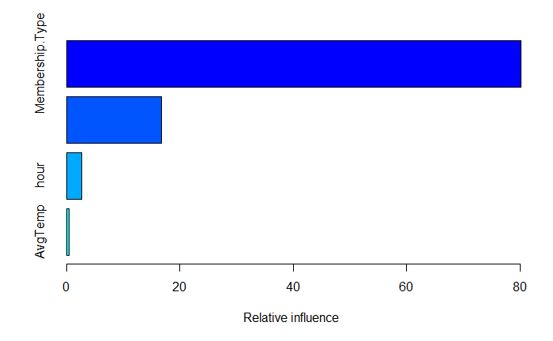

```r
summary(boost.merged)
```

```r
prob = predict(boost.merged, newdata = temp_merged[-train ,], type = "response")
```

```
Using 500 trees...
```

```r
yhat = ifelse(prob >.5,1,0)
sum(yhat)
```

```
[1] 1
```

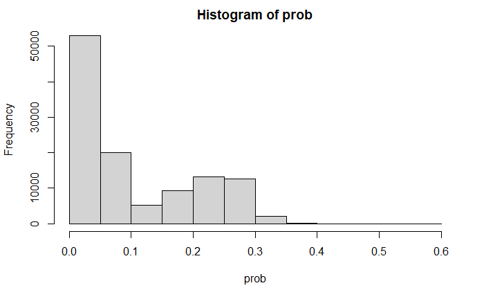

```r
hist(prob)
```

```r
yhat = ifelse(prob >.5,1,0)
cm = t(table(yhat, temp_merged$late[-train]))
cm
```

```
   yhat
         0      1
  0 103124      1
  1  12738      0
```

```r
sum(diag(cm))/sum(cm) #Accuracy
```

```
[1] 0.8900512
```

```r
cm[1,1]/sum(cm[1, c(1,2)]) #Correct rate of negative predicted values
```

```
[1] 0.9999903
```

```r
cm[2,2]/sum(cm[2, c(1,2)]) #Correct rate of positive predicted value
```

```
[1] 0
```

```r
yhat = ifelse(prob >.15,1,0)
cm = t(table(yhat, temp_merged$late[-train]))
cm
```

```
   yhat
        0     1
  0 74522 28603
  1  3786  8952
```

```r
sum(diag(cm))/sum(cm) #Accuracy
```

```
[1] 0.7204543
```

```r
cm[1,1]/sum(cm[1, c(1,2)]) #Correct rate of negative predicted values
```

```
[1] 0.7226376
```

```r
cm[2,2]/sum(cm[2, c(1,2)]) #Correct rate of positive predicted value
```

```
[1] 0.7027791
```